# Feasibility analysis for measuring clinical indicators in patients admitted with Heart Failure in NSLHD

Harrison Nguyen

05/07/2021

```r
library(magrittr)
library(targets)
library(tidyverse)
library(kableExtra)
library(ggplot2)
library(ggpubr)
library(acs)
library(flextable)
library(rmapaus)
source("R/definitions.R")
```

```r
hf_journey <- targets::tar_read(hf_journey)
hf_journey_demo_prep <- targets::tar_read(hf_journey_demo_prep)

hf_discharge_letter_keys <- targets::tar_read(hf_discharge_letter_keys)

hf_journey_meds_admit_discharge <- targets::tar_read(hf_journey_meds_admit_discharge)
hf_meds_discharge_sum <- targets::tar_read(hf_meds_discharge_sum)


hf_echo_procedures <- targets::tar_read(hf_echo_procedures)
```

# 1 Introduction

This is a feasibility analysis to examine clinical indicators in patients with encounters with a heart failure-related ICD-10 code (primary or additional). This feasibility analysis uses an existing 3-month EMR extract (1/4/17-30/6/17) in patients that presented with suspected acute coronary syndrome to NSLHD. We will examine subject demographics, whether patients have undergone specific investigations and/or procedures and the proportion of patients that have been discharged on specific medications.

This initial analysis will be performed in patients with encounters at RNSH with a primary or additional heart failure-related ICD10 code.

# 2 RNSH patient journeys with an ICD10 Heart Failure Primary Diagnosis

## 2.1 Cohort

### 2.1.1 Primary Diagnosis

This analysis was performed using patient journeys. Patient ‘journeys’ were defined as encounters where each encounter is separated by at most 24 hours from the following encounter that were designated the following ICD10 codes as a primary diagnosis:

```r
as.data.frame(hf_icd_codes()) %>%
  dplyr::rename(ICD10 = codes,Description=names) %>%
  knitr::kable()
```

| ICD10 | Description |
| --- | --- |
| I50.0 | Heart failure |
| I50.1 | Left venctricular failure, unspecified |
| I50.9 | Heart failure, unspecified |
| U82.2 | Chronic heart failure |
| I11.0 | Hypertensive heart disease with heart failure |
| I13.0 | Hypertensive heart and chronic kidney disease with heart failure and stage 1 through stage 4 chronic kidney disease, or unspecified chronic kidney disease |
| I13.2 | Hypertensive heart and chronic kidney disease with heart failure and with stage 5 chronic kidney disease, or end stage renal disease |

```r
facility_list <- c("Royal North Shore")
cohort_journey_keys <- hf_journey %>%
  dplyr::filter(FACILITY %in%  facility_list, DIAGNOSIS_IMPORTANCE == "primary_diagnosis") %>%
  dplyr::pull(JOURNEY_KEY)



primary_journey <- hf_journey %>%
  dplyr::filter(JOURNEY_KEY %in% cohort_journey_keys )

primary_journey_demo <-hf_journey_demo_prep %>%
  dplyr::filter(JOURNEY_KEY %in% cohort_journey_keys )

primary_meds <-hf_journey_meds_admit_discharge %>%
  dplyr::filter(JOURNEY_KEY %in% cohort_journey_keys )

primary_meds_sum <- hf_meds_discharge_sum %>%
  dplyr::filter(JOURNEY_KEY %in% cohort_journey_keys )

cohort_encounter_keys <- primary_journey %>%
  dplyr::distinct(ENCNTR_KEY)

primary_echo <- hf_echo_procedures %>%
  dplyr::filter(ENCNTR_KEY %in% cohort_encounter_keys )
```

```r
n_journeys <- dplyr::n_distinct(primary_journey$JOURNEY_KEY)
n_encounters <- dplyr::n_distinct(primary_journey$ENCNTR_KEY)
n_patients <- dplyr::n_distinct(primary_journey$PERSON_KEY)
```

```r
proportion_bar_plot <- function(df,column,title){
  plot<- df %>%
     ggplot2::ggplot(., aes(x=!!rlang::sym(column),fill=!!rlang::sym(column))) +
    ggplot2::geom_bar(aes(y = ..count..),stat="count",alpha=0.5,show.legend = FALSE) +
    ggplot2::xlab(title) +
    ggplot2::ylab("Count") +
    ggtitle(paste0(title, " (n = ",nrow(df), ")")) +
    geom_text(
       aes(label=paste(round((..count..)/sum(..count..)*100,0),"%",sep=""),y= ..count..),
       stat='count',
       vjust=-0.25
   ) +
  theme_minimal()

  return(plot)
}
```

Furthermore, the cohort selected have an admission date between **2017-04-01** - **2017-06-29** and includes any journeys that includes an encounter at **Royal North Shore**.

The analysis therefore includes n = **105** unique journeys with **121** encounters for **102** unique patients.

Figure 2.1 shows the distribution of ICD10 codes for the cohort.

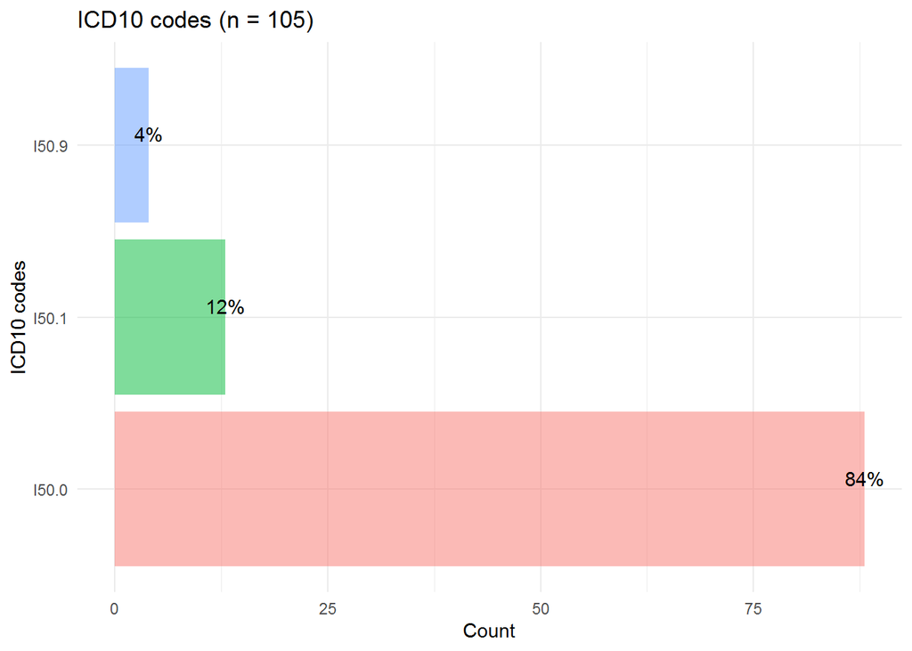

Figure 2.1: Distribution of ICD10 codes

```r
icd10_plot<- proportion_bar_plot(primary_journey_demo,"DISPLAY_IDENTIFIER_CAP","ICD10 codes")

icd10_plot  +
  coord_flip()
```

### 2.1.2 Primary and Additional Diagnosis

```r
cohort_journey_keys_secondary <- hf_journey %>%
  dplyr::filter(FACILITY %in%  facility_list, DIAGNOSIS_IMPORTANCE == "secondary_diagnosis" | DIAGNOSIS_IMPORTANCE == "primary_diagnosis") %>%
  dplyr::pull(JOURNEY_KEY)

secondary_journey_demo <- hf_journey_demo_prep %>%
  dplyr::filter(JOURNEY_KEY %in% cohort_journey_keys_secondary)

icd10_plot<- proportion_bar_plot(secondary_journey_demo,"DISPLAY_IDENTIFIER_CAP","Primary and Additional Diagnosis") +
  labs(x="ICD10 code")+
  coord_flip()
```

Another cohort is also defined by those with either a `primary` or `additional` heart failure diagnosis.

The cohort that includes a `additional` diagnosis of heart failure is larger (n = **522**) than those diagnosed with a primary diagnosis (n = **105**) and also includes encounters coded with `chronic heart failure`.

Figure 2.2 shows the distribution of both primary and additional ICD10 diagnosis, where there are n = **522** journeys with either a primary or additional diagnosis.

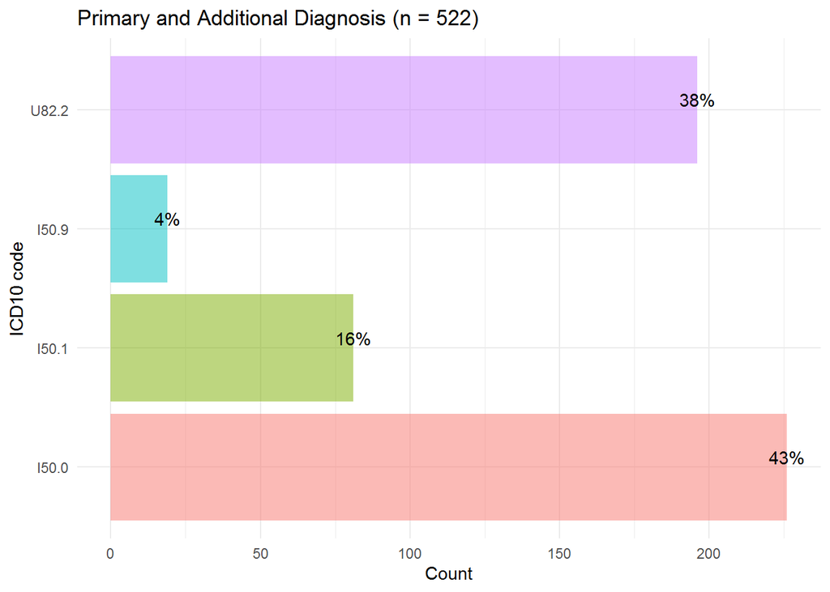

Figure 2.2: Distribution of primary and secondary heart failure ICD10 diagnosis.

```r
icd10_plot
```

### 2.1.3 Comparison against CaseMix App

The above numbers were compared against the in-house `Admitted Patient CaseMix app` developed by the NSLHD Performance and Analytics team that shows the numbers of encounters and their characteristics of each ICD10 diagnosis.

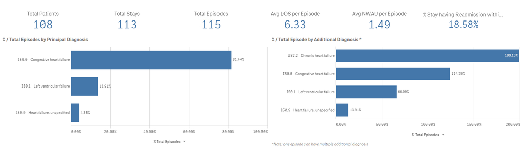

Figure 2.3: Distribution of ICD10 heart failure encounters using the `Admitted Patient CaseMix App.

```r
# All defaults
knitr::include_graphics(file.path(here::here(),"vignettes/img/clinical_app_hf_rns.png"))
```

## 2.2 Demographics

Table 2.1 shows the counts of males and females stratified by ICD10 diagnosis.

```r
total<- bind_rows(primary_journey_demo, mutate(primary_journey_demo, GENDER = "Total")) %>%
  group_by(GENDER) %>%
  summarise(
    N = n(),
    Age = round(mean(AGE_AT_ADMIT)),
  ) %>%
  pivot_wider(names_from = "GENDER", values_from = c("N", "Age")) %>%
  mutate(p_Female = round(N_Female/N_Total*100, 1),
         p_Male = round(N_Male/N_Total*100, 1)) %>%
  select(
         Females = N_Female, p_Female,
         Males = N_Male, p_Male,
         N_Total,
         Age_Female,
         Age_Male) %>%
  mutate(Group = "Total")


bind_rows(primary_journey_demo, mutate(primary_journey_demo, GENDER = "Total")) %>%
  group_by(DISPLAY_IDENTIFIER_CAP,GENDER) %>%
  summarise(
    N = n(),
    Age = round(mean(AGE_AT_ADMIT)),
  ) %>%
  pivot_wider(names_from = "GENDER", values_from = c("N", "Age")) %>%
  mutate(p_Female = round(N_Female/N_Total*100, 1),
         p_Male = round(N_Male/N_Total*100, 1)) %>%
  select(Group = DISPLAY_IDENTIFIER_CAP,
         Females = N_Female, p_Female,
         Males = N_Male, p_Male,
         N_Total,
         Age_Female,
         Age_Male) %>%
  bind_rows(total) %>%
  flextable() %>%
  set_header_labels(Group = "", p_Female = "%", p_Male = "%", N_Total = "n",
                    Age_Female = "Age (F)", Age_Male = "Age (M)") %>%
  set_caption("Male and Female counts and mean age stratified by ICD10 diagnosis.") %>%
  autofit()
```

Table 2.1: Male and Female counts and mean age stratified by ICD10 diagnosis.

|  | Females | % | Males | % | n | Age (F) | Age (M) |
| --- | --- | --- | --- | --- | --- | --- | --- |
| I50.0 | 41 | 46.6 | 47 | 53.4 | 88 | 85 | 84 |
| I50.1 | 5 | 38.5 | 8 | 61.5 | 13 | 82 | 74 |
| I50.9 | 1 | 25.0 | 3 | 75.0 | 4 | 79 | 88 |
| Total | 47 | 44.8 | 58 | 55.2 | 105 | 84 | 83 |

```r
conditional_bar_plot <- function(df,var1,var2,title){

  var1<- rlang::sym(var1)
  var2<- rlang::sym(var2)
  plot <- df%>%
  dplyr::count(!!var1,!!var2) %>%
  dplyr::group_by(!!var1) %>%
  dplyr::mutate(prop = prop.table(n)*100) %>%
  ggplot2::ggplot(., aes(x=!!var1,y=n,fill=!!var2)) +
  geom_bar(stat="identity",position=position_dodge(0.7),width=0.7,alpha=0.5) +
  geom_text(aes(label= paste(round(prop,0),"%",sep=""),y=n),position=position_dodge(0.7),vjust=-0.5) +
  labs(y="Count",x=var1, title = paste0(title, " (N = ",nrow(df), ")")) +
  scale_fill_discrete(name = var2) +
  theme_minimal()

  return(plot)
}
```

Figure 2.4 shows the distribution of sex according to age groups.

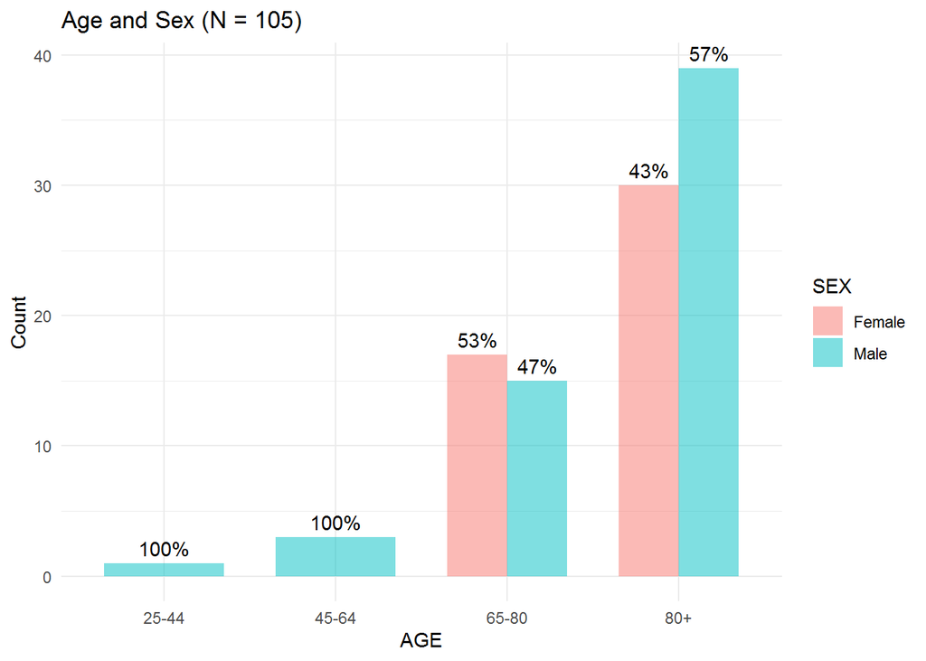

Figure 2.4: Distribution of Sex conditioned on Age.

```r
conditional_bar_plot(primary_journey_demo,"AGE_BINNED","GENDER", "Age and Sex") +
  scale_fill_discrete(name = "SEX") +
  xlab("AGE")
```

## 2.3 Patient Journey Characteristics

Figure 2.5 shows the characteristics of patient journeys such as presentation mode, whether the journey involved a transfer and the separation mode.

Most encounters are admitted into ED and most journeys either arrived by ambulance followed by self presentation and most journeys that include `Royal North Shore` begin at `Royal North Shore` rather than other hospitals in the local health district and shown by the journey trajectories in Figure 2.5c.

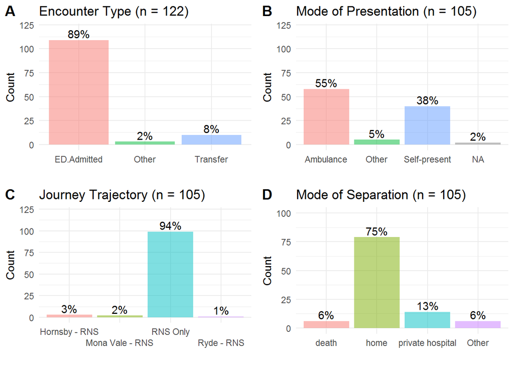

Figure 2.5: Characteristics of journeys.

```r
p1<-proportion_bar_plot(primary_journey, "ENCLASS", "Encounter Type") +
  xlab("") + ylim(0,120)

p2<- proportion_bar_plot(
  primary_journey_demo %>%
    dplyr::mutate(PRESENTATION_MODE = dplyr::case_when(
      stringr::str_detect(PRESENTATION_MODE,"triage")~ "Ambulance",
      TRUE ~ PRESENTATION_MODE)
    ), "PRESENTATION_MODE", "Mode of Presentation") + xlab("") + ylim(0,120)
p3 <- proportion_bar_plot(primary_journey_demo, "TRAJECTORY", "Journey Trajectory") +
  xlab("") + ylim(0,121) +
    scale_x_discrete(guide = guide_axis(n.dodge=2))
p4<-proportion_bar_plot(primary_journey_demo, "SEPARATION_MODE", "Mode of Separation") + xlab("")+ylim(0,100)



ggpubr::ggarrange(p1, p2, p3,p4,
          labels = c("A", "B", "C","D"),
          ncol = 2, nrow = 2)
```

Figure 2.6 shows that most journeys end at `Royal North Shore`.

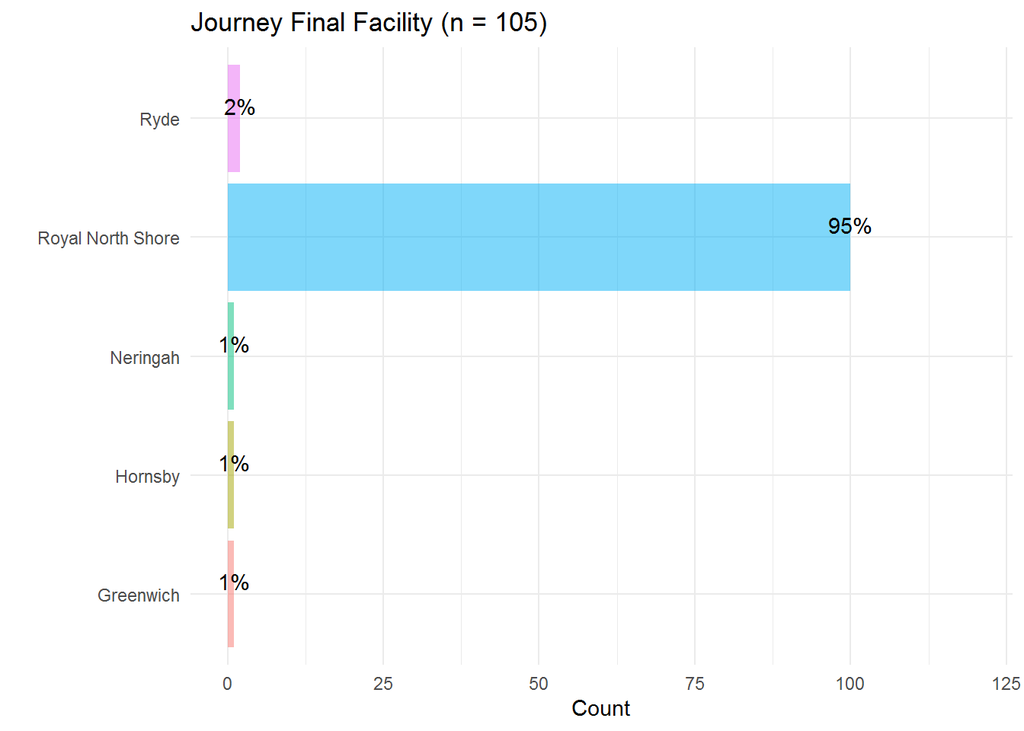

Figure 2.6: Final facility of journeys.

```r
p6<-proportion_bar_plot(primary_journey_demo, "JOURNEY_FINAL_FACILITY", "Journey Final Facility") + xlab("")+ylim(0,120) + coord_flip()
p6
```

## 2.4 Discharge Medications

Discharge medications were defined as journeys that had a discharge letter and excluded journeys that had a mode of separation of either **death, dama, private hospital**.

```r
hf_discharge_journeys <- primary_journey %>%
  dplyr::filter(ENCNTR_KEY %in% hf_discharge_letter_keys)

n_journeys_w_discharge <- dplyr::n_distinct(hf_discharge_journeys$JOURNEY_KEY)

## need to consider eplerenone
## https://www.ncbi.nlm.nih.gov/pmc/articles/PMC4814010/
```

**93.3**% (**98**/**105**) had a discharge letter and of those, **83.7**% (**82**/**98**) remained after the exclusion criteria.

Figure 2.7 shows the final facility of the those journeys that satisfy the criteria for a discharge medication and demonstrates that almost all discharges occur at `Royal North Shore`.

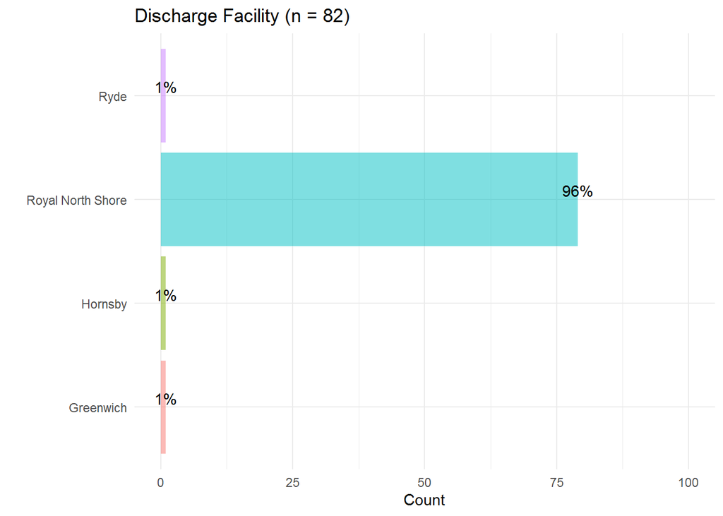

Figure 2.7: Distribution of discharge facility for journeys that satisfy the discharge medication criteria.

```r
proportion_bar_plot(primary_journey_demo %>%
  dplyr::filter(JOURNEY_KEY %in% primary_meds_sum$JOURNEY_KEY),
  "JOURNEY_FINAL_FACILITY",
  "Discharge Facility") + xlab("")+ylim(0,100) +coord_flip()
```

```r
ace<- hf_journey_meds_admit_discharge %>%
  dplyr::filter(MEDICATION == "A2RB/ACE Inhibitor") %>%
  dplyr::distinct(MEDICATION_NAME)

beta<- hf_journey_meds_admit_discharge %>%
  dplyr::filter(MEDICATION == "Beta blocker") %>%
  dplyr::distinct(MEDICATION_NAME)

diuretic<- hf_journey_meds_admit_discharge %>%
  dplyr::filter(MEDICATION == "Other diuretic") %>%
  dplyr::distinct(MEDICATION_NAME)
```

The medications examined include:

- ACE inhibitors such as **candesartan, perindopril, irbesartan**,
- beta blockers such as **propranolol, metoprolol, sotalol** and
- diuretics such as **spironolactone, hydrochlorothiazide, eplerenone**.

```r
wang_2013_reduced <- data.frame(
  list(medication=c("A2RB/ACE Inhibitor","Beta blocker", "Other diuretic"),
  percent=c(65.9,55.1,91.4),
  n=c(352,294,488))
)

wang_2013_preserved <- data.frame(
  list(medication=c("A2RB/ACE Inhibitor","Beta blocker", "Other diuretic"),
  percent=c(56.3,45.4,92.4),
  n=c(162,131,266))
)

med_table<-primary_meds_sum %>%
  mutate(`None of the above` = case_when(
    `Other diuretic` == 0 & `Beta blocker` == 0 & `A2RB/ACE Inhibitor` ==0 ~ 1,
    TRUE ~ 0
  )) %>%
  gather(medication, val, `Other diuretic`:`None of the above`) %>%
  mutate(val = val > 0) %>%
  group_by(medication) %>%
  summarise(percent = sum(val)/n()*100,n = sum(val), .groups = "drop") %>%
  slice(match(c("A2RB/ACE Inhibitor","Beta blocker", "Other diuretic","None of the above"), medication))
```

Table 2.2 shows a comparison to two different heart failure cohorts, one with reduced ejection fraction and preserved ejection fraction in Wang, Hales, and Tofler (2019).

```r
med_table %>%
  dplyr::mutate_if(is.numeric,funs(round(.,1))) %>%
  dplyr::left_join(wang_2013_reduced,by="medication",suffix=c("",".reduced")) %>%
  dplyr::left_join(wang_2013_preserved,by="medication",suffix=c("",".preserved")) %>%
  dplyr::select(medication,n,percent,n.reduced,percent.reduced,n.preserved,percent.preserved) %>%
  flextable() %>%
  set_header_labels(medication = "Medication", percent="ICD10 (%)", n="n ICD10",
                    percent.reduced = "HFrEF (%)",n.reduced =  "n HFrEF",
                    percent.preserved = "HFpEF (%)",n.preserved =  "n HFpEF") %>%
  footnote(i=1,
           j=c(2,4,6),
           value= as_paragraph(
             c("Cohort defined using heart failure ICD10 primary diagnosis.",
               "Data is from reduced ejection fraction cohort between 2013-2015.",
               "Data is from preserved ejection fraction cohort between 2013-2015.")),
              part = "header") %>%
  set_caption(caption = "Proportion of patients with a relevant medication discharge. Data from @wang201915 is used as reference. Note that @wang201915 excludes spironolactone for `Other diuretics`.")
```

Table 2.2: Proportion of patients with a relevant medication discharge. Data from Wang, Hales, and Tofler (2019) is used as reference. Note that Wang, Hales, and Tofler (2019) excludes spironolactone for `Other diuretics`.

| Medication | n ICD101 | ICD10 (%) | n HFrEF2 | HFrEF (%) | n HFpEF3 | HFpEF (%) |
| --- | --- | --- | --- | --- | --- | --- |
| A2RB/ACE Inhibitor | 41 | 50.0 | 352 | 65.9 | 162 | 56.3 |
| Beta blocker | 53 | 64.6 | 294 | 55.1 | 131 | 45.4 |
| Other diuretic | 21 | 25.6 | 488 | 91.4 | 266 | 92.4 |
| None of the above | 17 | 20.7 |  |  |  |  |

1Cohort defined using heart failure ICD10 primary diagnosis.  
2Data is from reduced ejection fraction cohort between 2013-2015.  
3Data is from preserved ejection fraction cohort between 2013-2015.

# 3 Primary or Additional Heart Failure Diagnosis

The above results focused on those with a primary ICD10 heart failure diagnosis. The next section examines those with a `primary` or `additional` ICD10 diagnosis.

```r
total<- bind_rows(secondary_journey_demo, mutate(secondary_journey_demo, GENDER = "Total")) %>%
  group_by(GENDER) %>%
  summarise(
    N = n(),
    Age = round(mean(AGE_AT_ADMIT)),
  ) %>%
  pivot_wider(names_from = "GENDER", values_from = c("N", "Age")) %>%
  mutate(p_Female = round(N_Female/N_Total*100, 1),
         p_Male = round(N_Male/N_Total*100, 1)) %>%
  select(
         Females = N_Female, p_Female,
         Males = N_Male, p_Male,
         N_Total,
         Age_Female,
         Age_Male) %>%
  mutate(Group = "Total")


bind_rows(secondary_journey_demo, mutate(secondary_journey_demo, GENDER = "Total")) %>%
  group_by(DISPLAY_IDENTIFIER_CAP,GENDER) %>%
  summarise(
    N = n(),
    Age = round(mean(AGE_AT_ADMIT)),
  ) %>%
  pivot_wider(names_from = "GENDER", values_from = c("N", "Age")) %>%
  mutate(p_Female = round(N_Female/N_Total*100, 1),
         p_Male = round(N_Male/N_Total*100, 1)) %>%
  select(Group = DISPLAY_IDENTIFIER_CAP,
         Females = N_Female, p_Female,
         Males = N_Male, p_Male,
         N_Total,
         Age_Female,
         Age_Male) %>%
  bind_rows(total) %>%
  flextable() %>%
  set_header_labels(Group = "", p_Female = "%", p_Male = "%", N_Total = "n",
                    Age_Female = "Age (F)", Age_Male = "Age (M)") %>%
  set_caption("Male and Female counts and mean age stratified by ICD10 diagnosis.") %>%
  autofit()
```

Table 3.1: Male and Female counts and mean age stratified by ICD10 diagnosis.

|  | Females | % | Males | % | n | Age (F) | Age (M) |
| --- | --- | --- | --- | --- | --- | --- | --- |
| I50.0 | 102 | 45.1 | 124 | 54.9 | 226 | 84 | 82 |
| I50.1 | 41 | 50.6 | 40 | 49.4 | 81 | 78 | 74 |
| I50.9 | 11 | 57.9 | 8 | 42.1 | 19 | 74 | 78 |
| U82.2 | 96 | 49.0 | 100 | 51.0 | 196 | 84 | 82 |
| Total | 250 | 47.9 | 272 | 52.1 | 522 | 83 | 80 |

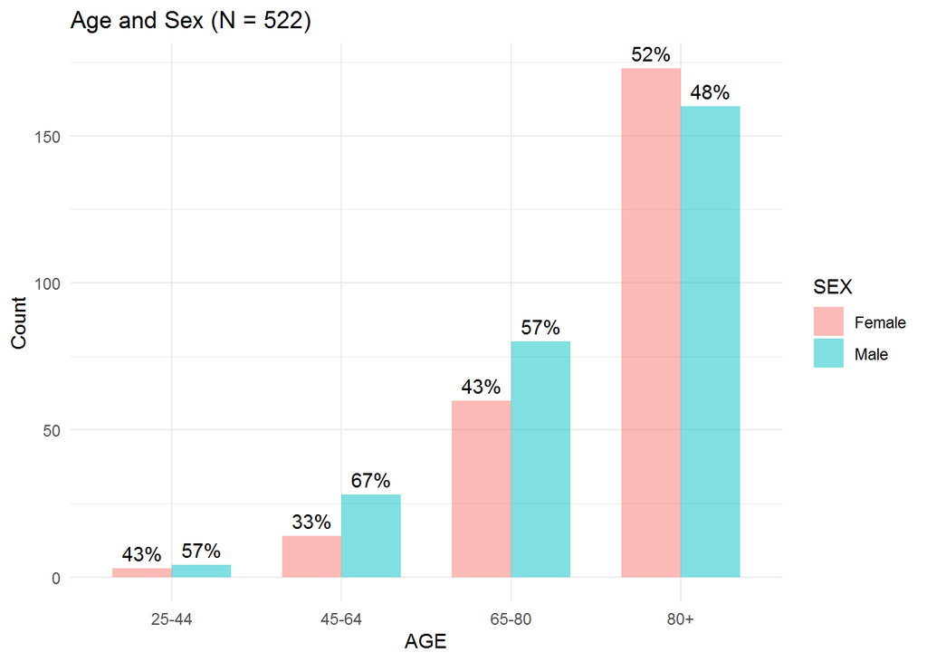

```r
conditional_bar_plot(secondary_journey_demo,"AGE_BINNED","GENDER", "Age and Sex") +
  scale_fill_discrete(name = "SEX") +
  xlab("AGE")
```

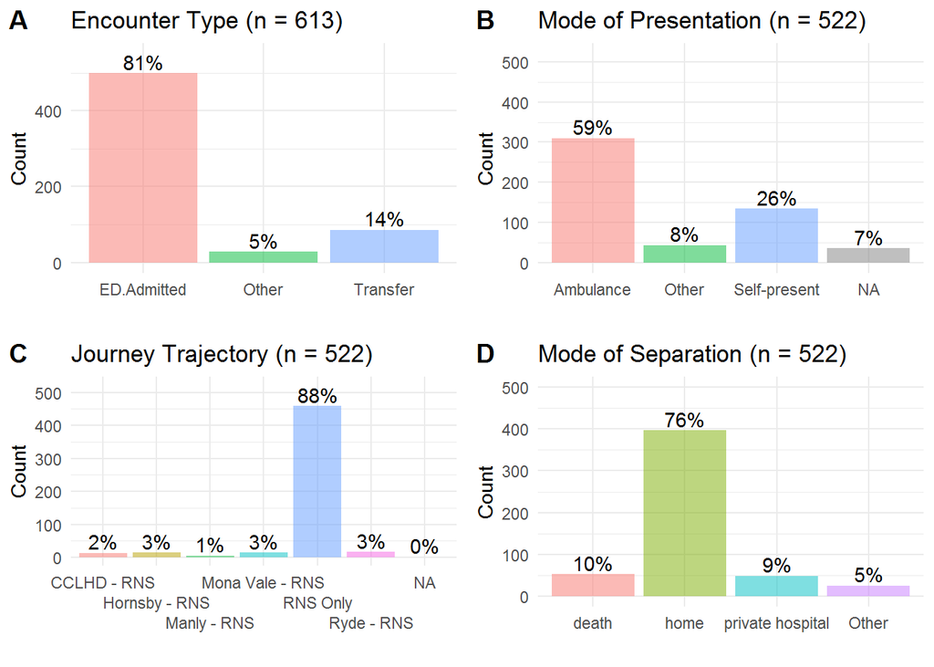

```r
secondary_journey <- hf_journey %>%
  dplyr::filter(JOURNEY_KEY %in% cohort_journey_keys_secondary )

p1<-proportion_bar_plot(secondary_journey, "ENCLASS", "Encounter Type") +
  xlab("") + ylim(0,550)

p2<- proportion_bar_plot(
  secondary_journey_demo %>%
    dplyr::mutate(PRESENTATION_MODE = dplyr::case_when(
      stringr::str_detect(PRESENTATION_MODE,"triage")~ "Ambulance",
      TRUE ~ PRESENTATION_MODE)
    ), "PRESENTATION_MODE", "Mode of Presentation") + xlab("") + ylim(0,520)
p3 <- proportion_bar_plot(secondary_journey_demo, "TRAJECTORY", "Journey Trajectory") +
  xlab("") + ylim(0,521) +
    scale_x_discrete(guide = guide_axis(n.dodge=3))
p4<-proportion_bar_plot(secondary_journey_demo, "SEPARATION_MODE", "Mode of Separation") + xlab("")+ylim(0,500)



ggpubr::ggarrange(p1, p2, p3,p4,
          labels = c("A", "B", "C","D"),
          ncol = 2, nrow = 2)
```

```r
secondary_meds_sum <- hf_meds_discharge_sum %>%
  dplyr::filter(JOURNEY_KEY %in% cohort_journey_keys_secondary )

secondary_med_table<-secondary_meds_sum %>%
  mutate(`None of the above` = case_when(
    `Other diuretic` == 0 & `Beta blocker` == 0 & `A2RB/ACE Inhibitor` ==0 ~ 1,
    TRUE ~ 0
  )) %>%
  gather(medication, val, `Other diuretic`:`None of the above`) %>%
  mutate(val = val > 0) %>%
  group_by(medication) %>%
  summarise(percent = sum(val)/n()*100,n = sum(val), .groups = "drop") %>%
  slice(match(c("A2RB/ACE Inhibitor","Beta blocker", "Other diuretic","None of the above"), medication))


secondary_med_table %>%
  dplyr::left_join(med_table,by="medication",suffix=c("",".primary")) %>%
  dplyr::mutate_if(is.numeric,funs(round(.,1))) %>%
  dplyr::left_join(wang_2013_reduced,by="medication",suffix=c("",".reduced")) %>%
  dplyr::left_join(wang_2013_preserved,by="medication",suffix=c("",".preserved")) %>%
  dplyr::select(medication,n,percent,n.primary,percent.primary,n.reduced,percent.reduced,n.preserved,percent.preserved) %>%
  flextable() %>%
  set_header_labels(medication = "Medication", percent="ICD10 (%)", n="N ICD10",
                    percent.reduced = "HFrEF (%)",n.reduced =  "N HFrEF",
                    percent.preserved = "HFpEF (%)",n.preserved =  "N HFpEF",
                    percent.primary="Only Primary ICD10",n.primary="N Only Primary ICD10") %>%
  footnote(i=1,
           j=c(2,4,6,8),
           value= as_paragraph(
             c("Cohort defined using heart failure ICD10 primary and additional diagnosis.",
               "Cohort defined using heart failure ICD10 primary diagnosis.",
               "Data is from reduced ejection fraction cohort between 2013-2015.",
               "Data is from preserved ejection fraction cohort between 2013-2015.")),
              part = "header") %>%
  set_caption(caption = "Proportion of patients with a relevant medication discharge. Data from @wang201915 is used as reference.")
```

Table 3.2: Proportion of patients with a relevant medication discharge. Data from Wang, Hales, and Tofler (2019) is used as reference.

| Medication | N ICD101 | ICD10 (%) | N Only Primary ICD102 | Only Primary ICD10 | N HFrEF3 | HFrEF (%) | N HFpEF4 | HFpEF (%) |
| --- | --- | --- | --- | --- | --- | --- | --- | --- |
| A2RB/ACE Inhibitor | 142 | 35.6 | 41 | 50.0 | 352 | 65.9 | 162 | 56.3 |
| Beta blocker | 193 | 48.4 | 53 | 64.6 | 294 | 55.1 | 131 | 45.4 |
| Other diuretic | 86 | 21.6 | 21 | 25.6 | 488 | 91.4 | 266 | 92.4 |
| None of the above | 138 | 34.6 | 17 | 20.7 |  |  |  |  |

1Cohort defined using heart failure ICD10 primary and additional diagnosis.  
2Cohort defined using heart failure ICD10 primary diagnosis.  
3Data is from reduced ejection fraction cohort between 2013-2015.  
4Data is from preserved ejection fraction cohort between 2013-2015.

There is a greater proportion of journeys with either a primary or additional diagnosis that have not been discharged with the relevant medication when compared to those only with a primary diagnosis.

Figure 3.1 shows the distribution of ICD codes with no discharge medication along with the type of diagnosis, whether `primary` or `additional` diagnosis. The groups that are typically not given medication on discharge are those with a `additional` heart failure diagnosis and those with `Chronic heart failure` makes the largest proportion of the group.

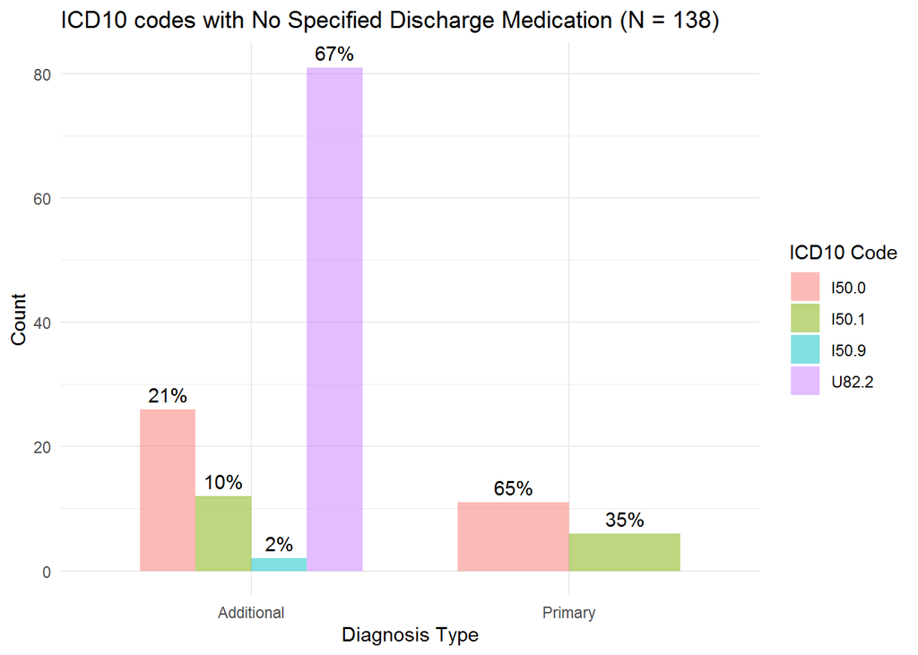

Figure 3.1: Distribution of ICD10 codes with no specified discharge medication.

```r
no_meds_journey_keys<- secondary_meds_sum %>%
  mutate(NONE = case_when(
    `Other diuretic` == 0 & `Beta blocker` == 0 & `A2RB/ACE Inhibitor` ==0 ~ 1,
    TRUE ~ 0
  )) %>%
  dplyr::filter(NONE == 1) %>%
  dplyr::pull(JOURNEY_KEY)

no_meds_journeys <- secondary_journey_demo %>%
  dplyr::filter(JOURNEY_KEY %in% no_meds_journey_keys) %>%
  dplyr::mutate(
    DIAGNOSIS_IMPORTANCE=dplyr::recode(DIAGNOSIS_IMPORTANCE, primary_diagnosis = "Primary", secondary_diagnosis = "Additional"))


conditional_bar_plot(no_meds_journeys,"DIAGNOSIS_IMPORTANCE","DISPLAY_IDENTIFIER_CAP", "ICD10 codes with No Specified Discharge Medication") +
  scale_fill_discrete(name = "ICD10 Code") +
  xlab("Diagnosis Type")
```

# 4 Reference

Wang, Nelson, Susan Hales, and Geoffrey Tofler. 2019. “15-Year Trends in Patients Hospitalised with Heart Failure and Enrolled in an Australian Heart Failure Management Program.” *Heart, Lung and Circulation* 28 (11): 1646–54.

# 5 Appendix

## 5.1 Demographics

Figure 5.1 shows the distribution of ICD10 codes conditioned on age and sex. The plots suggests that older age groups are more likely to be coded as having an ICD10 code of `I50.0 Heart failure` and are less likely to be coded as `I50.1 Left ventricular failure`. There seems to be no significant differences in diagnosis between sex.

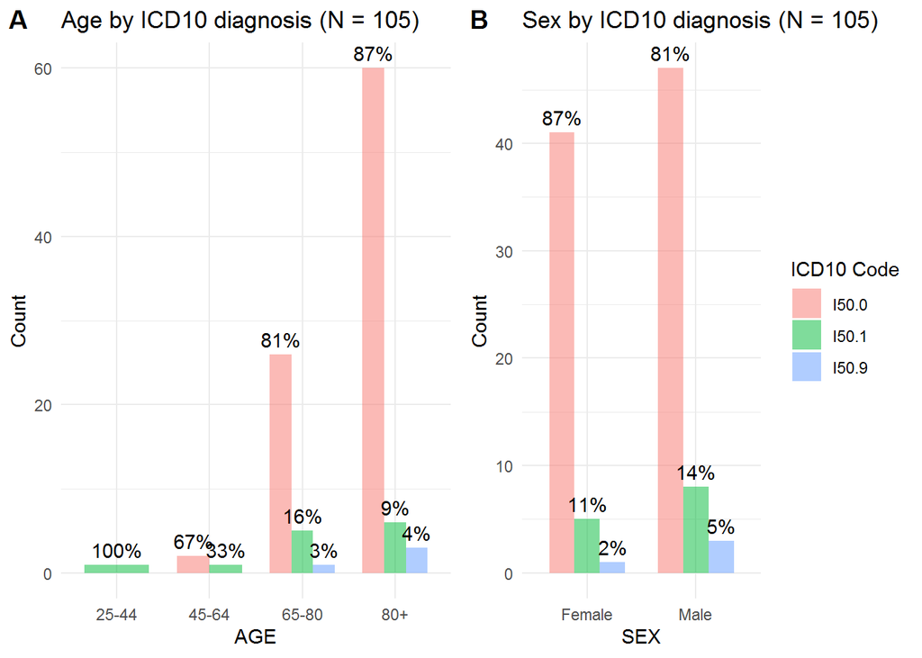

Figure 5.1: Distribution of ICD10 codes conditioned on sex and age.

```r
age_plot<-conditional_bar_plot(primary_journey_demo,"AGE_BINNED","DISPLAY_IDENTIFIER_CAP", "Age by ICD10 diagnosis") +
  xlab("AGE") + theme(legend.position = "none")


sex_plot<-conditional_bar_plot(primary_journey_demo,"GENDER","DISPLAY_IDENTIFIER_CAP", "Sex by ICD10 diagnosis") +
  scale_fill_discrete(name = "ICD10 Code") +
  xlab("SEX")



ggpubr::ggarrange(age_plot, sex_plot,
          labels = c("A", "B"),
          ncol = 2, nrow = 1)
```

Figure 5.2 shows a map of the distribution of postcodes for the cohort. There are a number of journeys where the patients had come from the Central Coast, however most have come from the Northern Sydney Region.

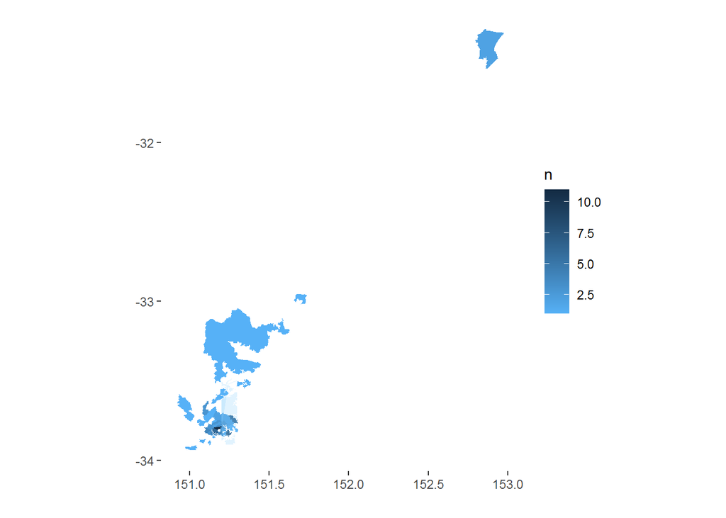

Figure 5.2: Map of postcodes and the number of journeys of the patient’s residential postcode.

```r
#count the number of times each postcode occurs
postcodes <- primary_journey_demo %>%
  select(CURRENT_POSTCODE) %>%
  count(CURRENT_POSTCODE, sort = T) %>%
  rename(POA_CODE = CURRENT_POSTCODE)
# get a map of NSW broad statistical areas (SSD)
ssd <- get_mapaus("SSD", accuracy="full")
nsw_map <- fortify(ssd[ssd$STATE=="NSW", ]) # create a nsw map
nsw <- filter(nsw_map, long < 151.3 & long > 151.2 & lat > -33.9 & lat < -33.3) # exclude Lord Howe
# get a map of australian postcodes
poa <- get_mapaus("POA", accuracy="full")
# Map the postcodes and fill by survey responses
p <-  mapfill(x = postcodes,
              map = poa,
              fill = "n",
              border = NA,
              ticks = TRUE,
              labels = FALSE)
# Add the NSW outline
p +
  scale_fill_gradient(low = "#56B1F7", high = "#132B43") +
  geom_polygon(data=nsw, aes(x=long, y=lat, group=id),
               color=NA, fill="lightskyblue", alpha = 0.25) +
  theme(panel.background = element_blank())
```

## 5.2 Investigations

We examine the number of echocardiograms that were performed in the cohort. Currently, the extract only contains transoesophageal echocardiographies or echocardiograms that were performed via an endoscope.

There are **14** transoesophageal echocardiograms in the extract. However **0** of the echos were associated with the cohort of interest.

Figure 5.3 shows the distribution of the admission time and the order of the echo procedure.

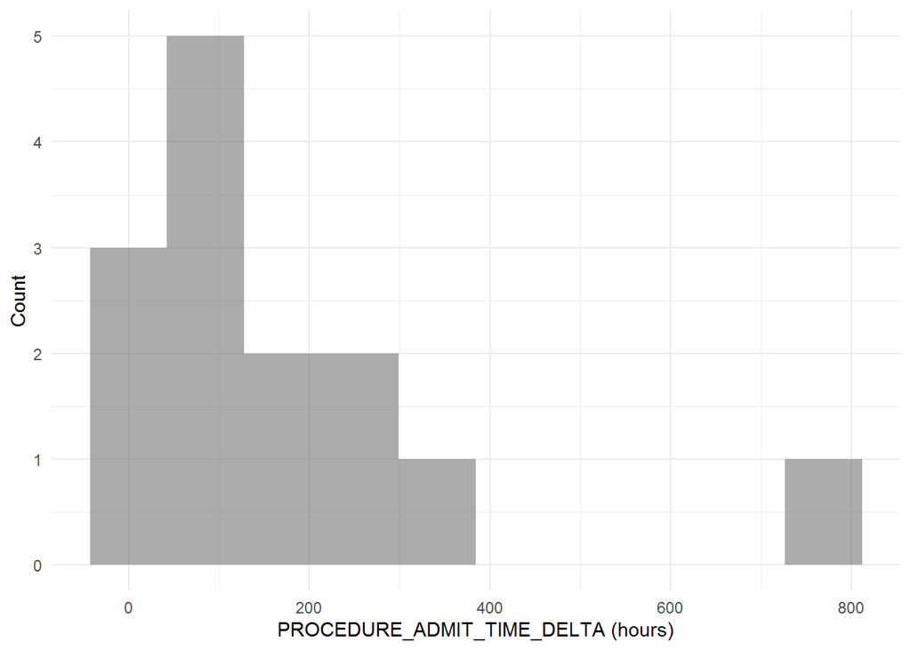

Figure 5.3: Distribution of the time difference between admission time and echocardiogram.

```r
ggplot(hf_echo_procedures, aes(x=PROCEDURE_ADMIT_TIME_DELTA)) + geom_histogram(bins=10,alpha=0.5) +
  labs(x="PROCEDURE_ADMIT_TIME_DELTA (hours)",y="Count") +
  theme_minimal()
```

## 5.3 Discharge Diagnosis and ICD10 Diagnosis Concordance

```r
hf_snomed_encounters <- targets::tar_read(hf_snomed_encounters)
hf_icd10_encounters <- targets::tar_read(hf_icd10_encounters)
fac_snomed_encounter <- hf_snomed_encounters %>%
  dplyr::filter(FACILITY %in% facility_list)

fac_icd10_encounter <- hf_icd10_encounters %>%
  dplyr::filter(FACILITY %in% facility_list)
```

We examine encounters with either a ICD10 or discharge (SNOMED) diagnosis of heart failure over the same period of time and facilities. This results in **103** ICD10 encounters and **38** SNOMED encounters with the following list of SNOMED codes:

```r
as.tibble(unique(fac_snomed_encounter$SOURCE_STRING_CAP)) %>% knitr::kable()
```

| value |
| --- |
| ACUTE EXACERBATION OF CHRONIC CONGESTIVE HEART FAILURE |
| BIVENTRICULAR FAILURE |
| CHRONIC LEFT-SIDED CONGESTIVE HEART FAILURE |
| CONGESTIVE HEART FAILURE |
| HEART FAILURE |
| CHF - CONGESTIVE HEART FAILURE |
| ACUTE HEART FAILURE |
| EXACERBATION OF CONGESTIVE HEART FAILURE |
| HF - HEART FAILURE |
| LEFT VENTRICULAR FAILURE |
| RIGHT HEART FAILURE DUE TO PULMONARY DISEASE |
| HEART FAILURE WITH NORMAL EJECTION FRACTION |
| HEART FAILURE WITH REDUCED EJECTION FRACTION |
| ACUTE CONGESTIVE HEART FAILURE |

```r
comb_encounters<-fac_icd10_encounter %>%
  dplyr::select(ENCNTR_KEY, SOURCE_STRING_CAP) %>%
  dplyr::full_join(
    dplyr::select(fac_snomed_encounter,ENCNTR_KEY,SOURCE_STRING_CAP),
    by="ENCNTR_KEY",
    suffix=c("_ICD10","_SNOMED")
  ) %>%
  dplyr::mutate(HAS_ICD10 = !is.na(SOURCE_STRING_CAP_ICD10),
                HAS_SNOMED = !is.na(SOURCE_STRING_CAP_SNOMED))

snomed_icd10<- table(comb_encounters$HAS_ICD10,comb_encounters$HAS_SNOMED)

prop_snomed_icd10<- prop.table(table(comb_encounters$HAS_ICD10,comb_encounters$HAS_SNOMED))
```

Taking the union of the two types of diagnosis codes together, there are **121** unique encounters.

Table 5.1 shows a contingency table between discharge diagnosis and ICD10 codes where only **16.5**% have both an ICD10 and SNOMED heart failure code.

```r
snomed_icd10 %>%
  knitr::kable(digits=2,caption = "Contigency table of discharge diagnosis and ICD10 code.") %>%
  kableExtra::add_header_above(c("Has ICD10"=1,"Has SNOMED"=2))
```

Table 5.1: Contigency table of discharge diagnosis and ICD10 code.

| Has ICD10 | Has SNOMED FALSE | Has SNOMED TRUE |
| --- | --- | --- |
| FALSE | 0 | 18 |
| TRUE | 83 | 20 |

```r
prop_snomed_icd10 %>%
  knitr::kable(digits=2, caption = "Contigency table of discharge diagnosis and ICD10 code as percentage.") %>%
  kableExtra::add_header_above(c("Has ICD10"=1,"Has SNOMED"=2))
```

Table 5.1: Contigency table of discharge diagnosis and ICD10 code as percentage.

| Has ICD10 | Has SNOMED FALSE | Has SNOMED TRUE |
| --- | --- | --- |
| FALSE | 0.00 | 0.15 |
| TRUE | 0.69 | 0.17 |